# Deferred Learning

Lukasz Brzozowski

24.04.2019

# 1 Oczyszczenie danych

Z danych usuwam jedynie zduplikowane kolumny.

```r
datY <- select(dat, Y)
dat <- select(dat, -Y)

datT <- t(dat)
datT1 <- unique(datT)
datT2 <- as.data.frame(t(datT1))
head(datT2, 3)
```

|  | Zuzanna | Lena | Maja | Hanna | Zofia | Amelia | Alicja | Aleksandra | Natalia | Wiktoria | Emilia | Antonina | Laura | Anna | Nadia | Pola | Liliana |
| --- | --- | --- | --- | --- | --- | --- | --- | --- | --- | --- | --- | --- | --- | --- | --- | --- | --- |
| 1 | 0 | 70 | 35 | 66 | 83 | 77 | 0 | 0 | 0 | 100 | 25 | 33 | 10 | 2 | 0 | 0 | 0 |
| 2 | 0 | 90 | 2 | 97 | 100 | 200 | 1 | 0 | 0 | 71 | 0 | 41 | 17 | 8 | 0 | 0 | 1 |
| 3 | 0 | 80 | 32 | 105 | 100 | 404 | 3 | 0 | 0 | 57 | 0 | 26 | 36 | 8 | 0 | 0 | 1 |

```r
summarizeColumns(datT2)
```

| name | type | na | mean | disp | median | mad | min | max | nlevs |
| --- | --- | --- | --- | --- | --- | --- | --- | --- | --- |
| Zuzanna | integer | 0 | 0.05568834 | 0.2293463 | 0 | 0.0000 | 0 | 1 | 0 |
| Lena | integer | 0 | 69.24856597 | 15.4163160 | 71 | 11.8608 | 20 | 94 | 0 |
| Maja | integer | 0 | 32.28130975 | 29.1380841 | 25 | 32.6172 | 0 | 154 | 0 |
| Hanna | integer | 0 | 74.07672084 | 37.6672535 | 73 | 31.1346 | 0 | 258 | 0 |
| Zofia | integer | 0 | 88.35898662 | 20.1109450 | 96 | 5.9304 | 20 | 100 | 0 |
| Amelia | integer | 0 | 183.29923518 | 108.4025349 | 176 | 96.3690 | 0 | 603 | 0 |
| Alicja | integer | 0 | 1.28824092 | 1.8370364 | 1 | 1.4826 | 0 | 20 | 0 |
| Aleksandra | integer | 0 | 0.05688337 | 0.2316473 | 0 | 0.0000 | 0 | 1 | 0 |
| Natalia | integer | 0 | 0.07289675 | 0.2599980 | 0 | 0.0000 | 0 | 1 | 0 |
| Wiktoria | integer | 0 | 62.79373805 | 26.3305229 | 67 | 25.2042 | 0 | 100 | 0 |

[output cut: 7 more lines]

# 2 TSNE - 1

Sprawdźmy, jak wygląda reprezentacja naszego zbioru danych w dwóch wymiarach.

```python
import pandas as pd
import numpy as np
import matplotlib.pyplot as plt
from sklearn.manifold import TSNE
from matplotlib.pyplot import figure

datP = pd.read_csv("datBY.csv")
tsne = TSNE()
tsne.fit(datP)
```

```
## TSNE(angle=0.5, early_exaggeration=12.0, init='random', learning_rate=200.0,
##    method='barnes_hut', metric='euclidean', min_grad_norm=1e-07,
##    n_components=2, n_iter=1000, n_iter_without_progress=300,
##    perplexity=30.0, random_state=None, verbose=0)
```

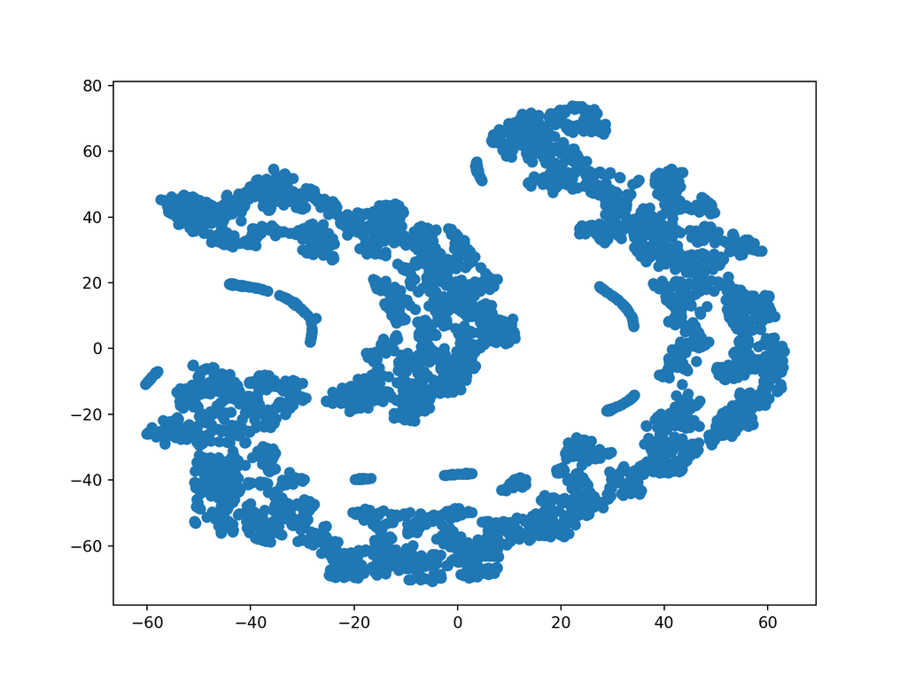

```python
plt.figure(figsize=(8,6))
plt.scatter(tsne.embedding_[:, 0], tsne.embedding_[:, 1])
plt.show()
```

Czy w powyższych danych mogą istnieć klastry?

# 3 Klasteryzacja

Do klasteryzacji używamy modelu `kkmeans` będącego ulepszeniem zwykłej metody k-średnich o przekształcenie w przestrzeń nieliniową, aby zmniejszyć wadę wyjściowej metody polegającą na nieodnajdowaniu klastrów, które nie są liniowo separowalne.

```r
performance(pred, measures = list(db, dunn), task = clustTask2)
```

```
##         db       dunn
## 0.99840427 0.02174618
```

Niski indeks Daviesa-Bouldina oznacza, że otrzymane klastry są do siebie podobne w sensie rozproszenia i wskazuje na dobrą klasteryzację, zaś niski indeks Dunna przeciwnie oznacza, że klastry “źle się zachowują” w przestrzeni euklidesowej. Pamiętajmy jednak, że użyta metoda klasteryzacji przekształca przestrzeń danych na przestrzeń nieliniową, zatem niekorzystny wynik w metryce euklidesowej nie oznacza złej klasteryzacji.

# 4 TSNE - 2

```python
import pandas as pd
import numpy as np
import matplotlib.pyplot as plt
from sklearn.manifold import TSNE
from matplotlib.pyplot import figure
tsne = TSNE()

datNew = pd.read_csv("datNew.csv")
tsne.fit(datNew)
```

```
## TSNE(angle=0.5, early_exaggeration=12.0, init='random', learning_rate=200.0,
##    method='barnes_hut', metric='euclidean', min_grad_norm=1e-07,
##    n_components=2, n_iter=1000, n_iter_without_progress=300,
##    perplexity=30.0, random_state=None, verbose=0)
```

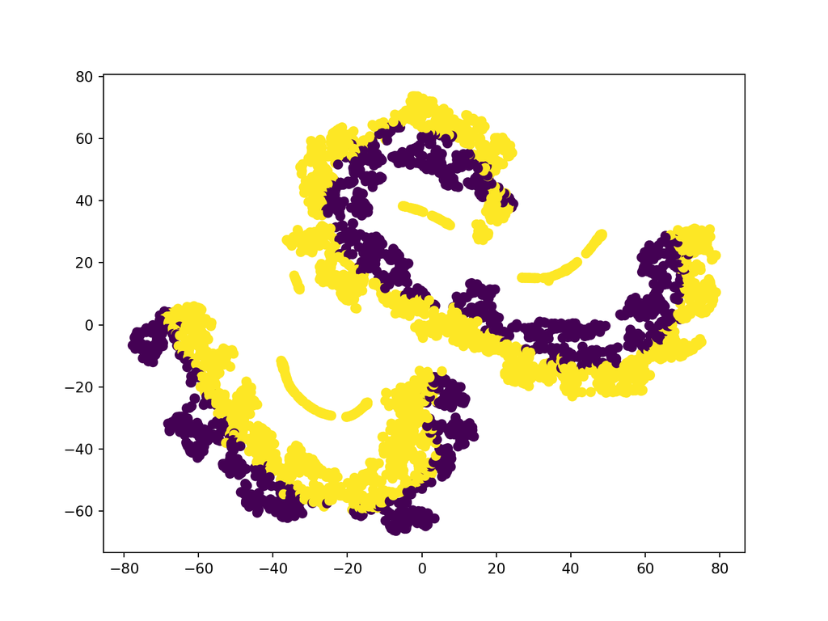

```python
plt.figure(figsize=(8,6))
plt.scatter(tsne.embedding_[:,0], tsne.embedding_[:,1], c=datNew['datProb1'])
```

Powyżej widzimy, jak są rozmieszczone oba klastry w reprezentacji algorytmem TSNE.

Możemy zatem przypuszczać, że podział na klastry będzie dostatecznie dobrze przybliżał podział na klasy, do których chcemy klasyfikować obserwacje.

# 5 Model

```r
r
```

```
## Resample Result
## Task: datNew
## Learner: classif.ksvm
## Aggr perf: acc.test.mean=0.9945028,auc.test.mean=0.9998857
## Runtime: 2.66031
```

## 5.1 Tuning parametru C

**Po optymalizacji bayesowskiej otrzymujemy C równe 4.902217**

## 5.2 Wyniki modelu

```r
rS
```

```
## Resample Result
## Task: datNew
## Learner: classif.ksvm
## Aggr perf: acc.test.mean=0.9940257,auc.test.mean=0.9998641
## Runtime: 1.63188
```

Pamiętajmy, że otrzymane `acc` i `auc` oznaczają, że model predykcyjny dobrze odwzorowuje działanie klasteryzacji, a nie klasyfikuje. Dopiero z wyników indeksów klasteryzacji możemy wnioskować, że takie podejście ma sens, nie jesteśmy jednak w stanie dokładnie przewidzieć, jakie wyniki osiągnie model.